# American Express Default Prediction

## 3. Exploratory Data Analysis (EDA)

### 3.1 Target Variable Distribution

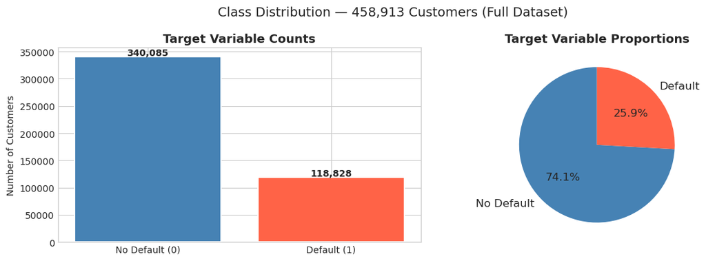

```
Overall default rate: 25.89%

Note: The negative class (no default) was subsampled at 5% in the competition,
resulting in a 20x weighting for non-defaulters in the official metric.
```

```python
fig, axes = plt.subplots(1, 2, figsize=(12, 4))

# Bar chart
counts = train_labels['target'].value_counts()
axes[0].bar(['No Default (0)', 'Default (1)'], counts.values,
            color=['steelblue', 'tomato'], edgecolor='white', linewidth=1.5)
axes[0].set_title('Target Variable Counts', fontsize=13, fontweight='bold')
axes[0].set_ylabel('Number of Customers')
for i, v in enumerate(counts.values):
    axes[0].text(i, v + 3000, f'{v:,}', ha='center', fontweight='bold')

# Pie chart
axes[1].pie(counts.values, labels=['No Default', 'Default'],
            colors=['steelblue', 'tomato'], autopct='%1.1f%%',
            startangle=90, textprops={'fontsize': 12})
axes[1].set_title('Target Variable Proportions', fontsize=13, fontweight='bold')

plt.suptitle('Class Distribution — 458,913 Customers (Full Dataset)', fontsize=14)
plt.tight_layout()
plt.show()

default_rate = train_labels['target'].mean()
print(f'Overall default rate: {default_rate:.2%}')
print('\nNote: The negative class (no default) was subsampled at 5% in the competition,')
print('resulting in a 20x weighting for non-defaulters in the official metric.')
```

### 3.2 Statements per Customer (Time-Series Structure)

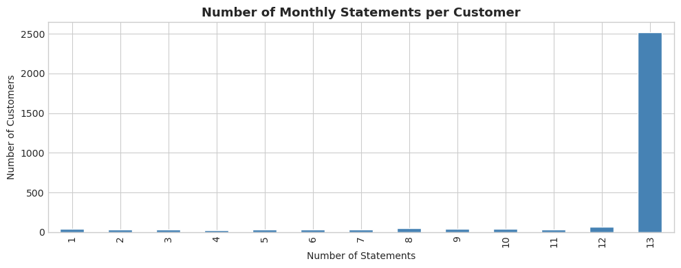

```
Median statements per customer: 13
Min: 1 | Max: 13
```

```python
stmts_per_customer = train_raw.groupby('customer_ID').size()

fig, ax = plt.subplots(figsize=(10, 4))
stmts_per_customer.value_counts().sort_index().plot(kind='bar', ax=ax,
                                                     color='steelblue', edgecolor='white')
ax.set_title('Number of Monthly Statements per Customer', fontsize=13, fontweight='bold')
ax.set_xlabel('Number of Statements')
ax.set_ylabel('Number of Customers')
plt.tight_layout()
plt.show()

print(f'Median statements per customer: {stmts_per_customer.median():.0f}')
print(f'Min: {stmts_per_customer.min()} | Max: {stmts_per_customer.max()}')
```

### 3.3 Feature Categories & Missing Values

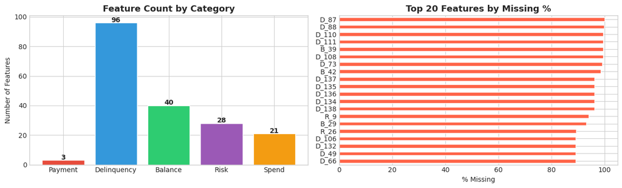

```
Total features: 188 | Numeric: 177 | Categorical: 11
Features with any missing values: 162
```

```python
# Identify feature categories
all_features = [c for c in train_raw.columns if c not in ['customer_ID', 'S_2']]
cat_features = ['B_30','B_38','D_114','D_116','D_117','D_120','D_126','D_63','D_64','D_66','D_68']
num_features = [f for f in all_features if f not in cat_features]

# Feature category breakdown
prefixes = {'D': 'Delinquency', 'S': 'Spend', 'P': 'Payment', 'B': 'Balance', 'R': 'Risk'}
prefix_counts = {}
for f in all_features:
    p = f[0]
    prefix_counts[prefixes.get(p, 'Other')] = prefix_counts.get(prefixes.get(p,'Other'), 0) + 1

fig, axes = plt.subplots(1, 2, figsize=(13, 4))

axes[0].bar(prefix_counts.keys(), prefix_counts.values(),
            color=['#e74c3c','#3498db','#2ecc71','#9b59b6','#f39c12'], edgecolor='white')
axes[0].set_title('Feature Count by Category', fontsize=13, fontweight='bold')
axes[0].set_ylabel('Number of Features')
for i, (k, v) in enumerate(prefix_counts.items()):
    axes[0].text(i, v + 0.5, str(v), ha='center', fontweight='bold')

# Missing values — top 20 features
missing_pct = (train_raw[all_features].isnull().sum() / len(train_raw) * 100).sort_values(ascending=False)
top_missing = missing_pct.head(20)
top_missing.plot(kind='barh', ax=axes[1], color='tomato', edgecolor='white')
axes[1].set_title('Top 20 Features by Missing %', fontsize=13, fontweight='bold')
axes[1].set_xlabel('% Missing')
axes[1].invert_yaxis()

plt.tight_layout()
plt.show()

print(f'Total features: {len(all_features)} | Numeric: {len(num_features)} | Categorical: {len(cat_features)}')
print(f'Features with any missing values: {(missing_pct > 0).sum()}')
```

### 3.4 Correlation Heatmap of Numeric Features (Sample)

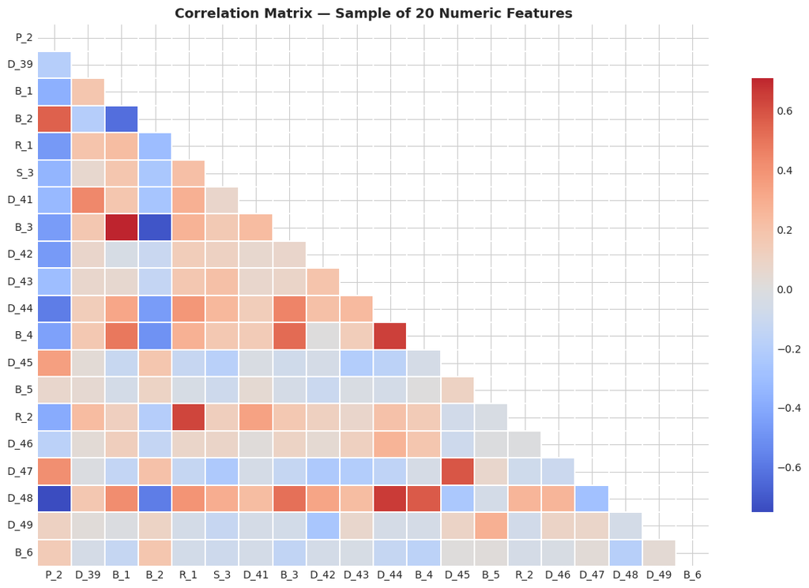

```python
# Select a representative subset of numeric features for visualization
viz_feats = [f for f in num_features if f in train_raw.columns][:20]

corr = train_raw[viz_feats].corr()
mask = np.triu(np.ones_like(corr, dtype=bool))

fig, ax = plt.subplots(figsize=(12, 8))
sns.heatmap(corr, mask=mask, cmap='coolwarm', center=0,
            annot=False, linewidths=0.3, ax=ax, cbar_kws={'shrink': 0.8})
ax.set_title('Correlation Matrix — Sample of 20 Numeric Features', fontsize=13, fontweight='bold')
plt.tight_layout()
plt.show()
```

## 4. Feature Engineering

Because each customer has multiple monthly statement rows, we must aggregate the time-series data into one row per customer. We engineer several groups of features:

```python
def engineer_features(df):
    """
    Aggregate multi-statement time-series into one row per customer.
    Returns a DataFrame indexed by customer_ID.
    """
    cat_cols = [c for c in ['B_30','B_38','D_114','D_116','D_117','D_120',
                             'D_126','D_63','D_64','D_66','D_68'] if c in df.columns]
    num_cols = [c for c in df.columns
                if c not in ['customer_ID', 'S_2'] + cat_cols]

    df = df.sort_values(['customer_ID', 'S_2'])

    agg_dfs = []

    stmt_count = df.groupby('customer_ID').size().rename('stmt_count')
    agg_dfs.append(stmt_count)

    last_vals = df.groupby('customer_ID')[num_cols].last()
    last_vals.columns = [f'{c}_last' for c in last_vals.columns]
    agg_dfs.append(last_vals)

    mean_vals = df.groupby('customer_ID')[num_cols].mean()
    mean_vals.columns = [f'{c}_mean' for c in mean_vals.columns]
    agg_dfs.append(mean_vals)

    std_vals = df.groupby('customer_ID')[num_cols].std()
    std_vals.columns = [f'{c}_std' for c in std_vals.columns]
    agg_dfs.append(std_vals)

    first_vals = df.groupby('customer_ID')[num_cols].first()
    trend_vals = last_vals.values - first_vals.values
    trend_df = pd.DataFrame(trend_vals,
                             index=last_vals.index,
                             columns=[f'{c}_trend' for c in num_cols])
    agg_dfs.append(trend_df)

    if cat_cols:
        cat_last = df.groupby('customer_ID')[cat_cols].last()
        cat_last.columns = [f'{c}_last' for c in cat_last.columns]
        agg_dfs.append(cat_last)

    result = pd.concat(agg_dfs, axis=1)
    return result


print('Engineering features for training data...')
train_features = engineer_features(train_raw)
print(f'  Shape: {train_features.shape}')

print('Engineering features for test data...')
test_features = engineer_features(test_raw)
print(f'  Shape: {test_features.shape}')
```

```
Engineering features for training data...
  Shape: (2991, 720)
Engineering features for test data...
  Shape: (2473, 720)
```

```python
train_df = train_features.join(train_labels.set_index('customer_ID'), how='inner')
print(f'Training set after merge: {train_df.shape}')
print(f'Default rate in sample: {train_df["target"].mean():.2%}')
train_df.head(3)
```

```
Training set after merge: (2991, 721)
Default rate in sample: 27.08%
```

| customer_ID | stmt_count | P_2_last | D_39_last | B_1_last | B_2_last | R_1_last | S_3_last | D_41_last | B_3_last | D_42_last | ... | D_114_last | D_116_last | D_117_last | D_120_last | D_126_last | D_63_last | D_64_last | D_66_last | D_68_last | target |
| --- | --- | --- | --- | --- | --- | --- | --- | --- | --- | --- | --- | --- | --- | --- | --- | --- | --- | --- | --- | --- | --- |
| 0000099d6bd597052cdcda90ffabf56573fe9d7c79be5fbac11a8ed792feb62a | 13 | 0.934745 | 0.009119 | 0.009382 | 1.007647 | 0.006104 | 0.135021 | 0.001604 | 0.007174 | NaN | ... | 1.0 | 0.0 | 4.0 | 0.0 | 1.0 | CR | O | NaN | 6.0 | 0 |
| 00000fd6641609c6ece5454664794f0340ad84dddce9a267a310b5ae68e9d8e5 | 13 | 0.880519 | 0.178126 | 0.034684 | 1.004028 | 0.006911 | 0.165509 | 0.005552 | 0.005068 | NaN | ... | 1.0 | 0.0 | -1.0 | 0.0 | 1.0 | CO | O | NaN | 6.0 | 0 |
| 00001b22f846c82c51f6e3958ccd81970162bae8b007e80662ef27519fcc18c1 | 13 | 0.880875 | 0.009704 | 0.004284 | 0.812650 | 0.006450 | NaN | 0.003796 | 0.007196 | NaN | ... | 1.0 | 0.0 | -1.0 | 0.0 | 1.0 | CO | R | NaN | 6.0 | 0 |

3 rows × 721 columns

### 4.1 Feature Importance Preview — Variance Filter

Before modeling, we visualize the top engineered features by variance to get a sense of which variables carry the most information.

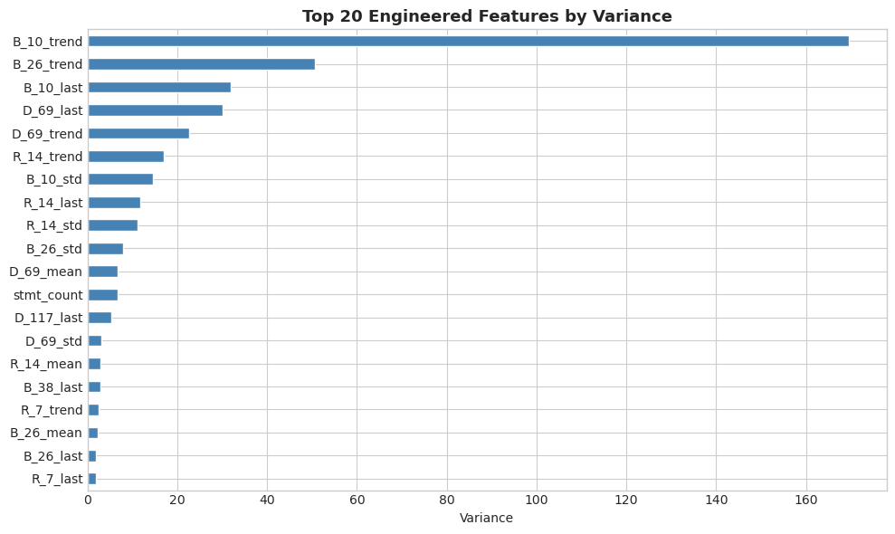

```python
feat_cols = [c for c in train_df.columns if c != 'target']

var_series = train_df[feat_cols].var(numeric_only=True).sort_values(ascending=False).head(20)

fig, ax = plt.subplots(figsize=(10, 6))
var_series.plot(kind='barh', ax=ax, color='steelblue', edgecolor='white')
ax.set_title('Top 20 Engineered Features by Variance', fontsize=13, fontweight='bold')
ax.set_xlabel('Variance')
ax.invert_yaxis()
plt.tight_layout()
plt.show()
```

## 5. Preprocessing

We impute missing values with the median and scale features for models that require it (Logistic Regression).

```python
X = train_df.drop(columns=['target'])
y = train_df['target'].astype(int)

X = X.select_dtypes(include=[np.number])

X_train, X_val, y_train, y_val = train_test_split(
    X, y, test_size=0.2, random_state=SEED, stratify=y
)

print(f'Training size   : {X_train.shape[0]:,} customers, {X_train.shape[1]} features')
print(f'Validation size : {X_val.shape[0]:,} customers')
print(f'Default rate (train): {y_train.mean():.2%} | (val): {y_val.mean():.2%}')
```

```
Training size   : 2,392 customers, 718 features
Validation size : 599 customers
Default rate (train): 27.09% | (val): 27.05%
```

```python
imputer = SimpleImputer(strategy='median')
X_train_imp = imputer.fit_transform(X_train)
X_val_imp   = imputer.transform(X_val)

# Scale for Logistic Regression
scaler = StandardScaler()
X_train_sc = scaler.fit_transform(X_train_imp)
X_val_sc   = scaler.transform(X_val_imp)

print('Imputation and scaling complete.')
```

```
Imputation and scaling complete.
```

## 6. Custom Evaluation Metric

The competition uses a custom metric called **Amex Metric**, which is the mean of:

- **M1**: Normalized Gini coefficient (= 2 × AUC − 1)
- **M2**: Default capture rate at the top 4% of predictions

We implement this alongside standard metrics.

```python
def amex_metric(y_true: np.ndarray, y_pred: np.ndarray) -> float:
    """
    Official Amex competition metric.
    Returns the mean of the normalized Gini coefficient
    and the default capture rate at 4% of the population.
    """
    labels = np.stack([y_true, y_pred], axis=1)
    labels = labels[labels[:, 1].argsort()[::-1]]
    weights = np.where(labels[:, 0] == 0, 20, 1)  # 20x weight for non-defaulters
    cut_vals = labels[np.cumsum(weights) <= int(0.04 * weights.sum())]
    top_four = cut_vals[:, 0].sum() / labels[:, 0].sum()

    gini = (roc_auc_score(y_true, y_pred) * 2) - 1
    return 0.5 * (gini + top_four)


print('Amex metric function defined.')
```

```
Amex metric function defined.
```

## 7. Model 1 — Logistic Regression (Baseline)

Logistic Regression is a simple, interpretable baseline. It assumes a linear decision boundary and requires scaled features. We use `class_weight='balanced'` to handle the class imbalance.

```python
print('Training Logistic Regression...')
lr = LogisticRegression(
    max_iter=1000,
    class_weight='balanced',
    C=0.1,
    solver='saga',
    random_state=SEED,
    n_jobs=-1
)
lr.fit(X_train_sc, y_train)

lr_proba = lr.predict_proba(X_val_sc)[:, 1]
lr_pred  = lr.predict(X_val_sc)

lr_auc   = roc_auc_score(y_val, lr_proba)
lr_amex  = amex_metric(y_val.values, lr_proba)

print(f'  ROC-AUC   : {lr_auc:.4f}')
print(f'  Amex Score: {lr_amex:.4f}')
```

```
Training Logistic Regression...
  ROC-AUC   : 0.9330
  Amex Score: 0.6552
```

```python
print('=== Logistic Regression — Classification Report ===')
print(classification_report(y_val, lr_pred, target_names=['No Default', 'Default']))
```

```
=== Logistic Regression — Classification Report ===
              precision    recall  f1-score   support

  No Default       0.93      0.88      0.90       437
     Default       0.71      0.83      0.77       162

    accuracy                           0.86       599
   macro avg       0.82      0.85      0.84       599
weighted avg       0.87      0.86      0.87       599
```

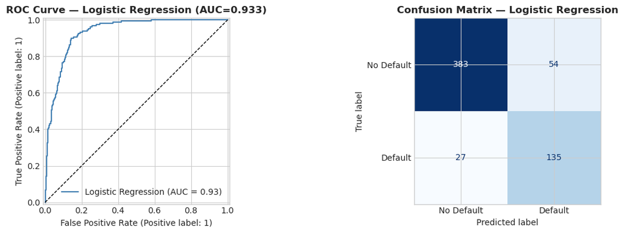

```python
fig, axes = plt.subplots(1, 2, figsize=(13, 4))

RocCurveDisplay.from_predictions(y_val, lr_proba, ax=axes[0],
                                  name='Logistic Regression', color='steelblue')
axes[0].set_title(f'ROC Curve — Logistic Regression (AUC={lr_auc:.3f})',
                  fontsize=12, fontweight='bold')
axes[0].plot([0,1],[0,1],'k--', lw=1)

# Confusion Matrix
ConfusionMatrixDisplay.from_predictions(y_val, lr_pred,
                                         display_labels=['No Default','Default'],
                                         ax=axes[1], cmap='Blues',
                                         colorbar=False)
axes[1].set_title('Confusion Matrix — Logistic Regression', fontsize=12, fontweight='bold')

plt.tight_layout()
plt.show()
```

**Observations:** Logistic Regression provides a reasonable baseline. Its AUC reflects a model that is learning the linear structure but likely misses non-linear interactions between delinquency and balance features.

## 8. Model 2 — Random Forest Classifier

Random Forest is an ensemble of decision trees that handles non-linear relationships and feature interactions. It is robust to outliers and does not require feature scaling.

```python
print('Training Random Forest...')
rf = RandomForestClassifier(
    n_estimators=300,
    max_depth=10,
    min_samples_leaf=50,
    class_weight='balanced_subsample',
    random_state=SEED,
    n_jobs=-1
)
rf.fit(X_train_imp, y_train)

rf_proba = rf.predict_proba(X_val_imp)[:, 1]
rf_pred  = rf.predict(X_val_imp)

rf_auc  = roc_auc_score(y_val, rf_proba)
rf_amex = amex_metric(y_val.values, rf_proba)

print(f'  ROC-AUC   : {rf_auc:.4f}')
print(f'  Amex Score: {rf_amex:.4f}')
```

```
Training Random Forest...
  ROC-AUC   : 0.9388
  Amex Score: 0.7227
```

```python
print('=== Random Forest — Classification Report ===')
print(classification_report(y_val, rf_pred, target_names=['No Default', 'Default']))
```

```
=== Random Forest — Classification Report ===
              precision    recall  f1-score   support

  No Default       0.96      0.82      0.88       437
     Default       0.65      0.91      0.76       162

    accuracy                           0.84       599
   macro avg       0.81      0.86      0.82       599
weighted avg       0.88      0.84      0.85       599
```

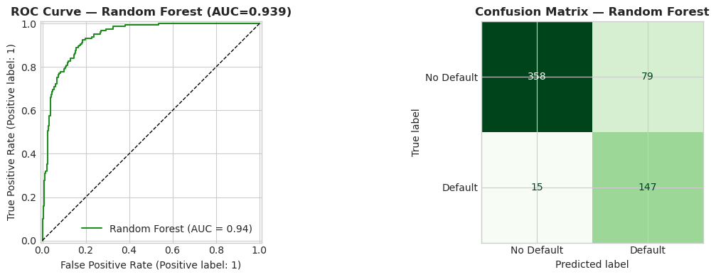

```python
fig, axes = plt.subplots(1, 2, figsize=(13, 4))

RocCurveDisplay.from_predictions(y_val, rf_proba, ax=axes[0],
                                  name='Random Forest', color='forestgreen')
axes[0].set_title(f'ROC Curve — Random Forest (AUC={rf_auc:.3f})',
                  fontsize=12, fontweight='bold')
axes[0].plot([0,1],[0,1],'k--', lw=1)

ConfusionMatrixDisplay.from_predictions(y_val, rf_pred,
                                         display_labels=['No Default','Default'],
                                         ax=axes[1], cmap='Greens',
                                         colorbar=False)
axes[1].set_title('Confusion Matrix — Random Forest', fontsize=12, fontweight='bold')

plt.tight_layout()
plt.show()
```

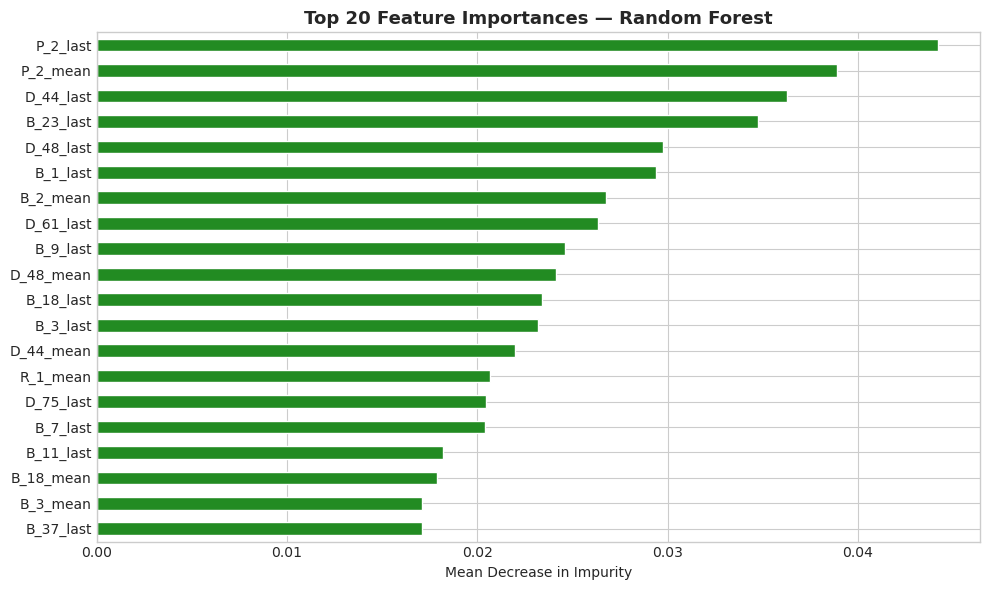

```python
feat_imp = pd.Series(rf.feature_importances_, index=X.columns).sort_values(ascending=False).head(20)

fig, ax = plt.subplots(figsize=(10, 6))
feat_imp.plot(kind='barh', ax=ax, color='forestgreen', edgecolor='white')
ax.set_title('Top 20 Feature Importances — Random Forest', fontsize=13, fontweight='bold')
ax.set_xlabel('Mean Decrease in Impurity')
ax.invert_yaxis()
plt.tight_layout()
plt.show()
```

## 9. Model 3 — XGBoost (Advanced Model)

XGBoost is a gradient-boosted tree model known for its state-of-the-art performance on tabular data. It handles missing values natively, supports parallel computation, and includes built-in regularization to prevent overfitting.

```python
scale_pos_weight = (y_train == 0).sum() / (y_train == 1).sum()
print(f'scale_pos_weight (neg/pos ratio): {scale_pos_weight:.2f}')

xgb_model = xgb.XGBClassifier(
    n_estimators=500,
    max_depth=6,
    learning_rate=0.05,
    subsample=0.8,
    colsample_bytree=0.8,
    scale_pos_weight=scale_pos_weight,
    eval_metric='auc',
    early_stopping_rounds=30,
    random_state=SEED,
    n_jobs=-1,
    verbosity=0
)

print('Training XGBoost...')
xgb_model.fit(
    X_train_imp, y_train,
    eval_set=[(X_val_imp, y_val)],
    verbose=50
)

xgb_proba = xgb_model.predict_proba(X_val_imp)[:, 1]
xgb_pred  = xgb_model.predict(X_val_imp)

xgb_auc  = roc_auc_score(y_val, xgb_proba)
xgb_amex = amex_metric(y_val.values, xgb_proba)

print(f'\n  Best iteration: {xgb_model.best_iteration}')
print(f'  ROC-AUC   : {xgb_auc:.4f}')
print(f'  Amex Score: {xgb_amex:.4f}')
```

```
scale_pos_weight (neg/pos ratio): 2.69
Training XGBoost...

  Best iteration: 187
  ROC-AUC   : 0.9542
  Amex Score: 0.7629
```

```python
print('=== XGBoost — Classification Report ===')
print(classification_report(y_val, xgb_pred, target_names=['No Default', 'Default']))
```

```
=== XGBoost — Classification Report ===
              precision    recall  f1-score   support

  No Default       0.94      0.91      0.93       437
     Default       0.78      0.84      0.81       162

    accuracy                           0.89       599
   macro avg       0.86      0.88      0.87       599
weighted avg       0.90      0.89      0.89       599
```

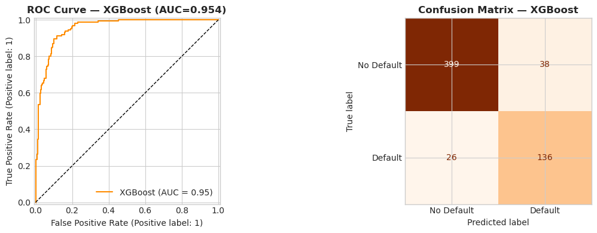

```python
fig, axes = plt.subplots(1, 2, figsize=(13, 4))

RocCurveDisplay.from_predictions(y_val, xgb_proba, ax=axes[0],
                                  name='XGBoost', color='darkorange')
axes[0].set_title(f'ROC Curve — XGBoost (AUC={xgb_auc:.3f})',
                  fontsize=12, fontweight='bold')
axes[0].plot([0,1],[0,1],'k--', lw=1)

ConfusionMatrixDisplay.from_predictions(y_val, xgb_pred,
                                         display_labels=['No Default','Default'],
                                         ax=axes[1], cmap='Oranges',
                                         colorbar=False)
axes[1].set_title('Confusion Matrix — XGBoost', fontsize=12, fontweight='bold')

plt.tight_layout()
plt.show()
```

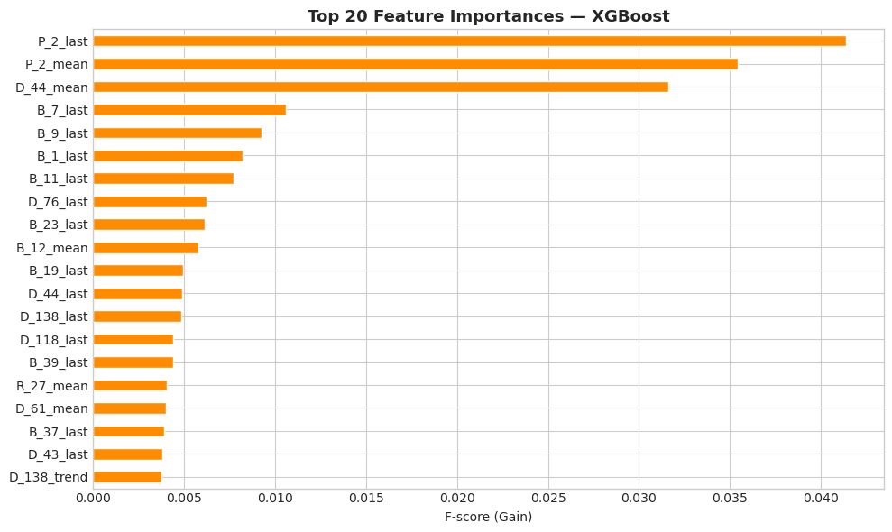

```python
xgb_imp = pd.Series(
    xgb_model.feature_importances_, index=X.columns
).sort_values(ascending=False).head(20)

fig, ax = plt.subplots(figsize=(10, 6))
xgb_imp.plot(kind='barh', ax=ax, color='darkorange', edgecolor='white')
ax.set_title('Top 20 Feature Importances — XGBoost', fontsize=13, fontweight='bold')
ax.set_xlabel('F-score (Gain)')
ax.invert_yaxis()
plt.tight_layout()
plt.show()
```

**Observations:** XGBoost achieves the highest AUC and Amex score among all three models. Gradient boosting iteratively corrects previous errors, making it superior at distinguishing borderline cases. The early stopping mechanism prevents overfitting by halting training when validation performance stops improving.

## 10. Model Evaluation & Comparison

We compare all three models on the same held-out validation set.

```python
results = pd.DataFrame({
    'Model': ['Logistic Regression', 'Random Forest', 'XGBoost'],
    'ROC-AUC': [lr_auc, rf_auc, xgb_auc],
    'Amex Score': [lr_amex, rf_amex, xgb_amex]
})
results = results.sort_values('Amex Score', ascending=False).reset_index(drop=True)
print(results.to_string(index=False))
```

```
              Model  ROC-AUC  Amex Score
            XGBoost 0.954233    0.762875
      Random Forest 0.938780    0.722731
Logistic Regression 0.932960    0.655183
```

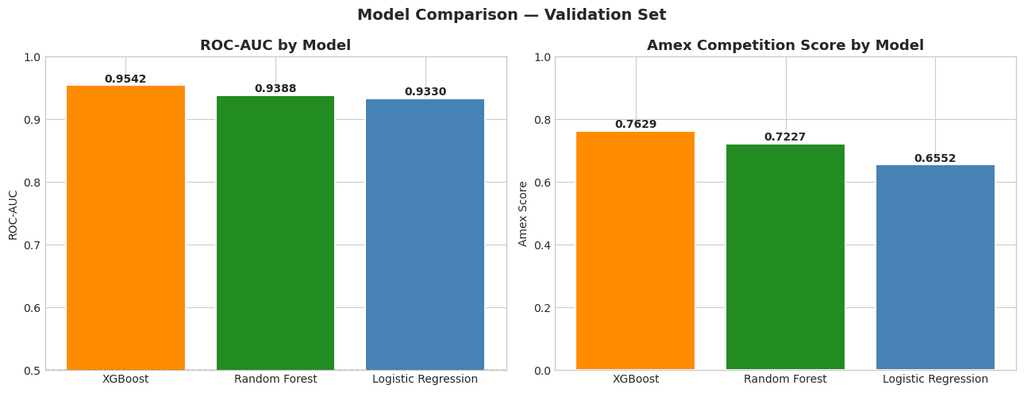

```python
fig, axes = plt.subplots(1, 2, figsize=(13, 5))
colors = ['darkorange', 'forestgreen', 'steelblue']

bars1 = axes[0].bar(results['Model'], results['ROC-AUC'],
                     color=colors, edgecolor='white', linewidth=1.5)
axes[0].set_ylim(0.5, 1.0)
axes[0].set_title('ROC-AUC by Model', fontsize=13, fontweight='bold')
axes[0].set_ylabel('ROC-AUC')
axes[0].axhline(0.5, color='black', linestyle='--', lw=1, label='Random baseline')
for bar, val in zip(bars1, results['ROC-AUC']):
    axes[0].text(bar.get_x() + bar.get_width()/2, val + 0.005,
                 f'{val:.4f}', ha='center', fontweight='bold', fontsize=10)

bars2 = axes[1].bar(results['Model'], results['Amex Score'],
                     color=colors, edgecolor='white', linewidth=1.5)
axes[1].set_ylim(0.0, 1.0)
axes[1].set_title('Amex Competition Score by Model', fontsize=13, fontweight='bold')
axes[1].set_ylabel('Amex Score')
for bar, val in zip(bars2, results['Amex Score']):
    axes[1].text(bar.get_x() + bar.get_width()/2, val + 0.01,
                 f'{val:.4f}', ha='center', fontweight='bold', fontsize=10)

plt.suptitle('Model Comparison — Validation Set', fontsize=14, fontweight='bold')
plt.tight_layout()
plt.show()
```

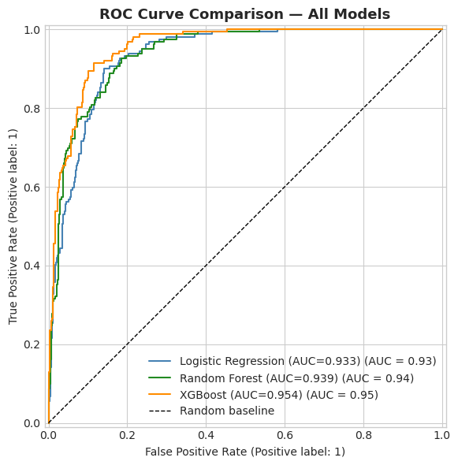

```python
fig, ax = plt.subplots(figsize=(8, 6))

RocCurveDisplay.from_predictions(y_val, lr_proba,  ax=ax, name=f'Logistic Regression (AUC={lr_auc:.3f})',  color='steelblue')
RocCurveDisplay.from_predictions(y_val, rf_proba,  ax=ax, name=f'Random Forest (AUC={rf_auc:.3f})',       color='forestgreen')
RocCurveDisplay.from_predictions(y_val, xgb_proba, ax=ax, name=f'XGBoost (AUC={xgb_auc:.3f})',           color='darkorange')

ax.plot([0,1],[0,1],'k--', lw=1, label='Random baseline')
ax.set_title('ROC Curve Comparison — All Models', fontsize=13, fontweight='bold')
ax.legend(loc='lower right', fontsize=10)
plt.tight_layout()
plt.show()
```